# 6_1_BenchmarkModels_FittedValues_Forecasts

## 2. Extract and plot the seasonally adjusted data

```
Plot variable not specified, automatically selected `.vars = season_adjust`
```

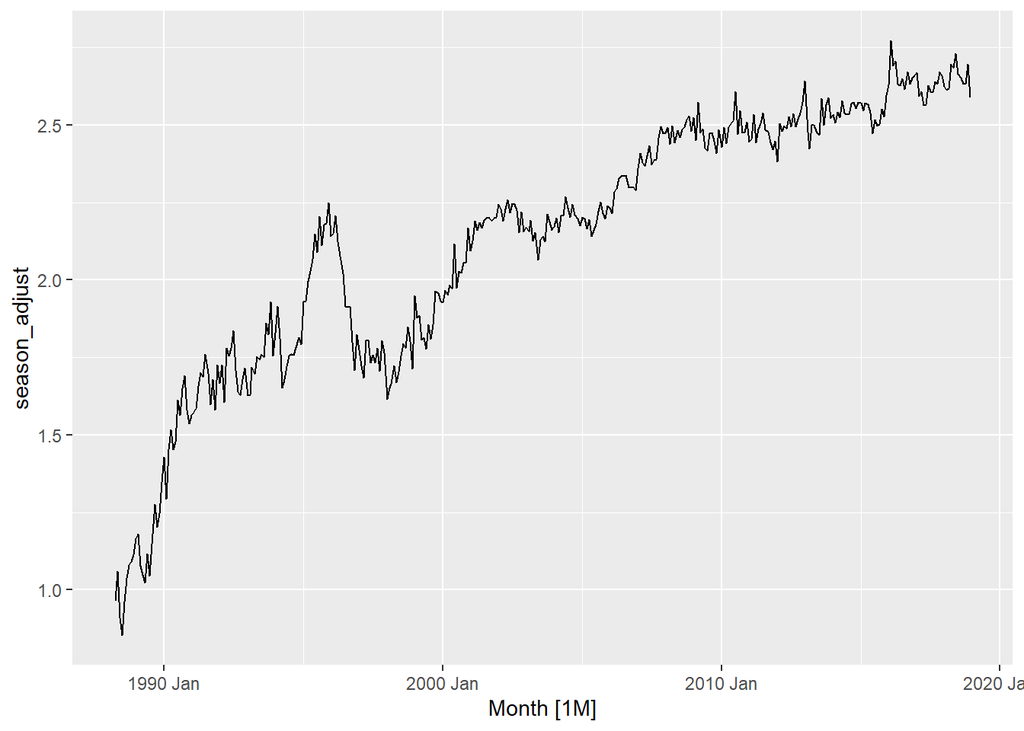

```r
season_adjust <- dcmp %>% select(season_adjust)
season_adjust %>% autoplot()
```

## 3. Use the drift method to produce forcasts of the seasonally adjusted data. Generate a graph with the tieme series, the fitted values and the forecasts

```r
        retail_series %>%
        model(stl = STL(log_T)) %>%
        components() %>%
        model(Drift = RW(season_adjust ~ drift()))
```

```
# A mable: 1 x 4
# Key:     State, Industry, .model [1]
  State              Industry                               .model         Drift
  <chr>              <chr>                                  <chr>        <model>
1 Northern Territory Clothing, footwear and personal acces… stl    <RW w/ drift>
```

```r
# Fit the model
fit_drift <- season_adjust %>%
             model(Drift = RW(season_adjust ~ drift()))

fitted_vals_drift <- fit_drift %>% augment()

forecasts <- fit_drift %>% forecast(h = 36)
head(forecasts)
```

```
# A fable: 6 x 4 [1M]
# Key:     .model [1]
  .model    Month  season_adjust .mean
  <chr>     <mth>         <dist> <dbl>
1 Drift  2019 Jan N(2.6, 0.0037)  2.59
2 Drift  2019 Feb N(2.6, 0.0075)  2.60
3 Drift  2019 Mar  N(2.6, 0.011)  2.60
4 Drift  2019 Apr  N(2.6, 0.015)  2.60
5 Drift  2019 May  N(2.6, 0.019)  2.61
6 Drift  2019 Jun  N(2.6, 0.023)  2.61
```

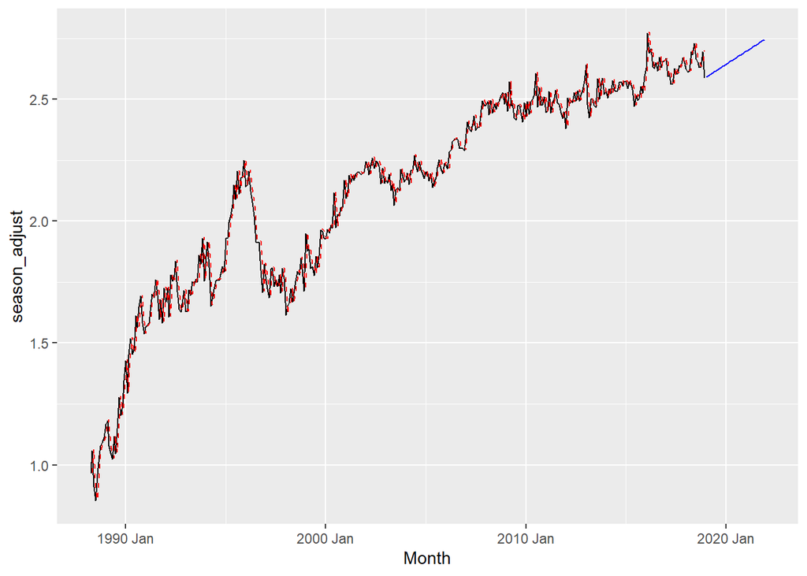

```r
forecasts %>% autoplot(season_adjust, level = FALSE) +
              autolayer(fitted_vals_drift, .fitted, colour = "red", linetype = "dashed")
```

## 4. Use the SNAIVE method to produce forecasts of the seasonal component. Generate a graph with the time series, the fitted values and the forecasts

```r
seasonal <- select(dcmp, season_year)
seasonal
```

```
# A tsibble: 369 x 2 [1M]
   season_year    Month
         <dbl>    <mth>
 1    -0.131   1988 Apr
 2     0.00568 1988 May
 3     0.0443  1988 Jun
 4     0.177   1988 Jul
 5     0.103   1988 Aug
 6     0.0602  1988 Sep
 7     0.0525  1988 Oct
 8     0.00579 1988 Nov
 9     0.322   1988 Dec
10    -0.173   1989 Jan
# … with 359 more rows
```

```r
fit_snaive <- seasonal %>% model(SNaive = SNAIVE(season_year ~ lag("year")))
fit_snaive
```

```
# A mable: 1 x 1
    SNaive
   <model>
1 <SNAIVE>
```

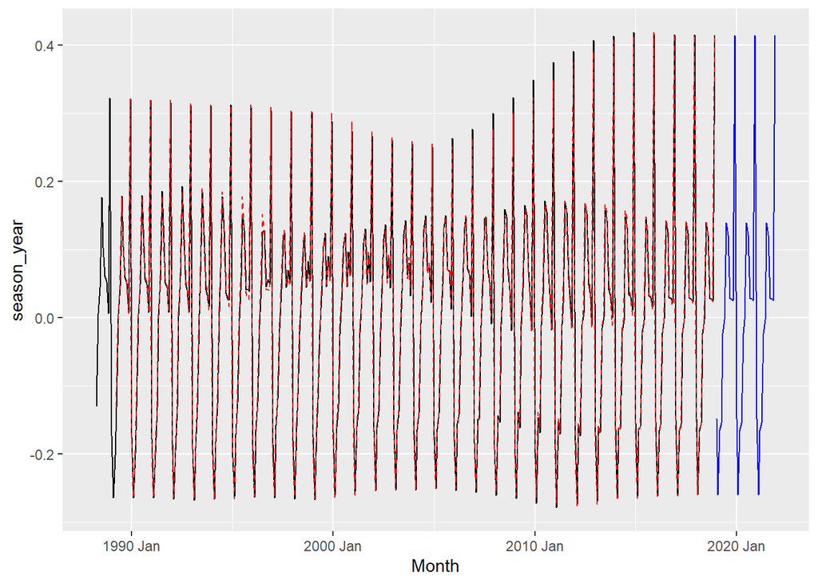

```r
fitted_vals_snaive <- fit_snaive %>% augment()

forecasts_snaive <- fit_snaive %>% forecast(h = 36)

forecasts_snaive %>%
  autoplot(seasonal, level = FALSE) +
  autolayer(fitted_vals_snaive, .fitted, colour = "red", linetype = "dashed")
```

## 5. Use `decomposition_model()` to generate a model that combines the two approaches used in points 3 and 4.

```r
OPTION 1: specify transformation within the model specification.
The forecasts will be automatically converted to the original variable.
This is the preferred option
```

```r
fit_dcmp <- retail_series %>%
  model(
    decomp = decomposition_model(
                # Specify the decomposition scheme to be used.
                STL(log(Turnover) ~ trend(window = 21) + season(window = 13)),
                # Specify a model for the seasonally adjusted component (in this case, a drift).
                RW(season_adjust ~ drift()),
                # Specify a model for the seasonal component (unnecesary, since SNAIVE is the default).
                SNAIVE(season_year)
            )
  )

fit_dcmp
```

```
# A mable: 1 x 3
# Key:     State, Industry [1]
  State              Industry                                             decomp
  <chr>              <chr>                                               <model>
1 Northern Territory Clothing, footwear and personal … <STL decomposition model>
```

```r
fitted_vals <- fit_dcmp %>% augment()
fitted_vals
```

```
# A tsibble: 369 x 8 [1M]
# Key:       State, Industry, .model [1]
   State              Industry     .model    Month Turno…¹ .fitted .resid .innov
   <chr>              <chr>        <chr>     <mth>   <dbl>   <dbl>  <dbl>  <dbl>
 1 Northern Territory Clothing, f… decomp 1988 Apr     2.3      NA     NA     NA
 2 Northern Territory Clothing, f… decomp 1988 May     2.9      NA     NA     NA
 3 Northern Territory Clothing, f… decomp 1988 Jun     2.6      NA     NA     NA
 4 Northern Territory Clothing, f… decomp 1988 Jul     2.8      NA     NA     NA
 5 Northern Territory Clothing, f… decomp 1988 Aug     2.9      NA     NA     NA
 6 Northern Territory Clothing, f… decomp 1988 Sep     3        NA     NA     NA
 7 Northern Territory Clothing, f… decomp 1988 Oct     3.1      NA     NA     NA
 8 Northern Territory Clothing, f… decomp 1988 Nov     3        NA     NA     NA
 9 Northern Territory Clothing, f… decomp 1988 Dec     4.2      NA     NA     NA
10 Northern Territory Clothing, f… decomp 1989 Jan     2.7      NA     NA     NA
# … with 359 more rows, and abbreviated variable name ¹Turnover
```

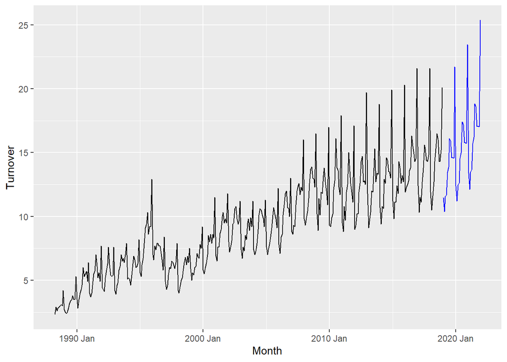

```r
fit_dcmp %>%
  forecast(h = 36) %>%
  autoplot(retail_series, level = FALSE)
```

```r
OPTION 2: specify transformation on a separate column (create new variable)
This works on the transformed domain and does not automatically back-transform
the forecasts.

OPTION 1 is preferred because it automatically converts the forecasts back
```

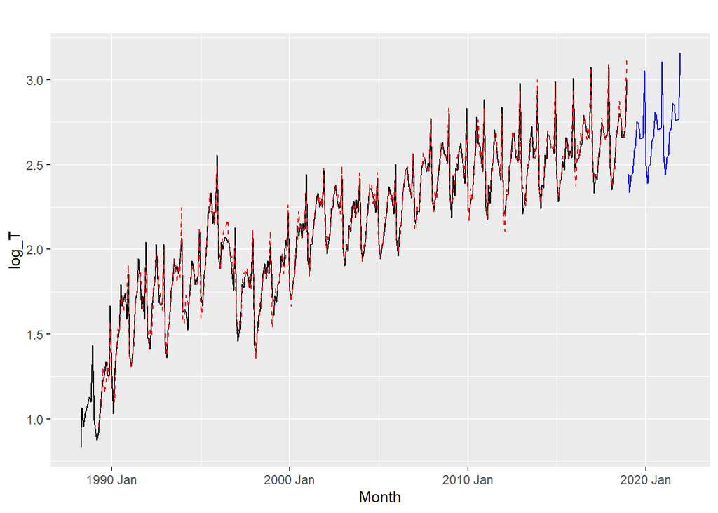

```r
log_T_series <- select(retail_series, log_T)

fit_dcmp_2 <- log_T_series %>%
  model(stlf = decomposition_model(
        STL(log_T), # Details how to decompose the series
        RW(season_adjust ~ drift()) # Details model for the seasonally adjusted component
  ))

fitted_vals_2 <- fit_dcmp_2 %>% augment()

fit_dcmp_2 %>%
  forecast(h = 36) %>%
  autoplot(log_T_series, level = FALSE) +
  autolayer(fitted_vals_2, .fitted, colour = "red", linetype = "dashed") +
  labs(y = "log_T",
       title = "")
```

```
Plot variable not specified, automatically selected `.vars = Turnover`
```

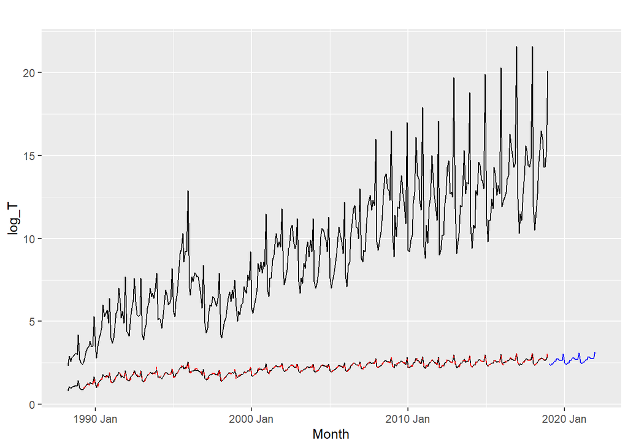

```r
# Let us show the original time series to see the difference between the original
# and the transformed domain
fit_dcmp_2 %>%
  forecast(h = 36) %>%
  autoplot(log_T_series, level = FALSE) +
  autolayer(fitted_vals_2, .fitted, colour = "red", linetype = "dashed") +
  labs(y = "log_T",
       title = "") +

  autolayer(retail_series)
```